# EC7025 - SFC

# System of (in)dependent equations

> See Fenell et. al (2016)
- The Gauss-Seidel has to be used only in the case of system of dependent equations
- In other case, we only need to find order in which each variable is computed and simply compute the new value in each period
- This order is the “logical causal order” of the model and can be visualized using Direct (A)Cyclical Graphs

## Direct Acyclic graphs

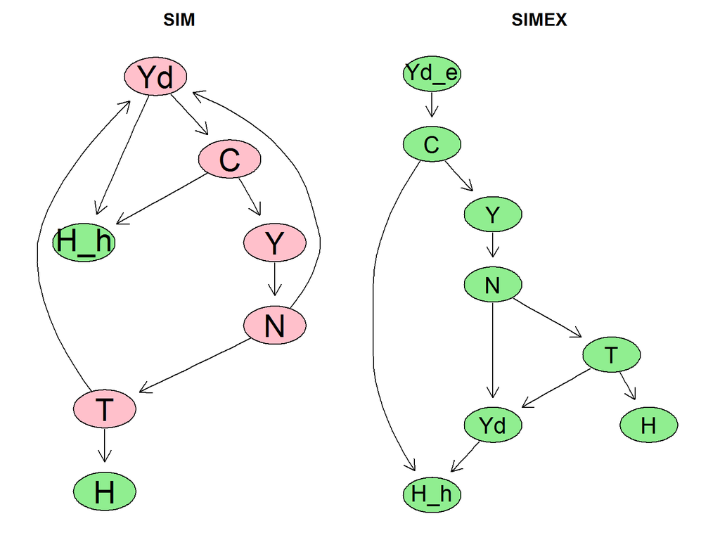

```r
simex<-sfc.model("SIMEX.txt",modelName="SIMplest model with expectation")
layout(matrix(c(1,2),1,2))
plot.dag(sim,main="SIM" )
plot.dag(simex,main="SIMEX" )
```

## In the case of a more complex model - Chapter 6

- We can generate the plots that allow us to delve into the actual structure of the system.
- Nodes that do not form a cycle are green while nodes that form a cycle in the system are pink.
- The Gauss-Seidel needs to be applied only for the cycles

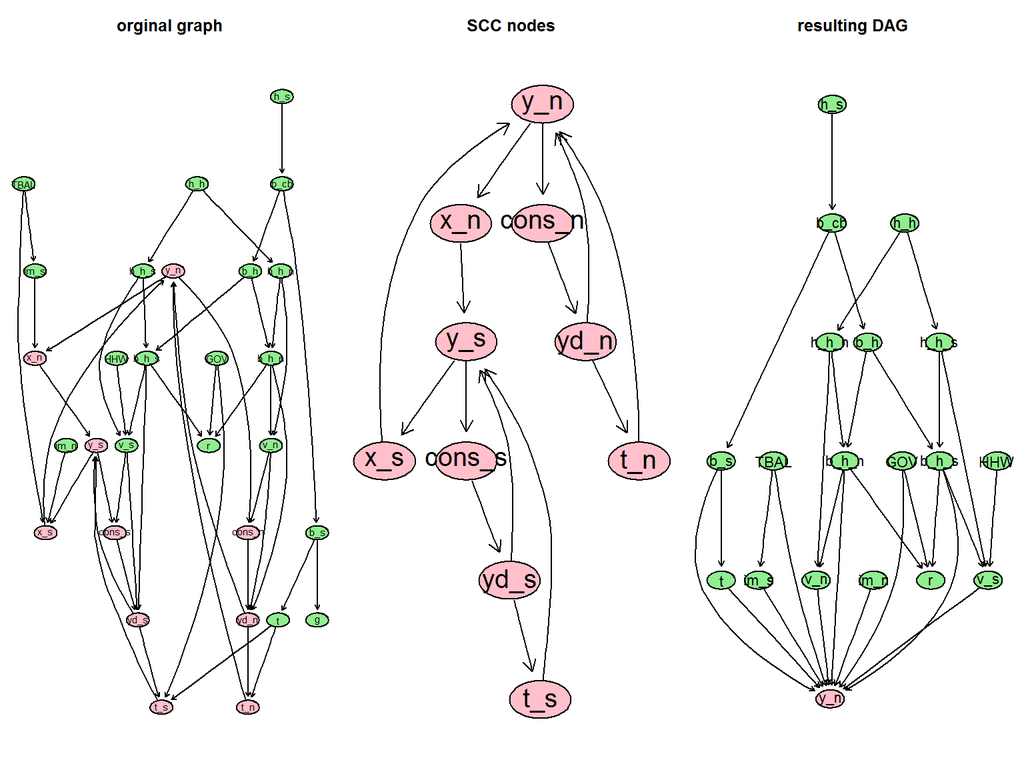

```r
ch6 <- sfc.model("ch6.txt",modelName="Chapter6_openmodel")
graphs = generate.DAG.collapse( adjacency = ch6$matrix )
par(mfrow = c(1,3))
# first plot the orgianl grpah
plot_graph_hierarchy( graphs$orginal_graph, main = "orginal graph" )
# plot hte nodes that form the strongly connected compoent
plot_graph_hierarchy( graphs$SCC_graph, main = "SCC nodes" )
# plot the result ing DAG when we take the condensation of the graph
plot_graph_hierarchy( graphs$DAG, main = "resulting DAG" )
```

## Systems of dependent vs independent equations

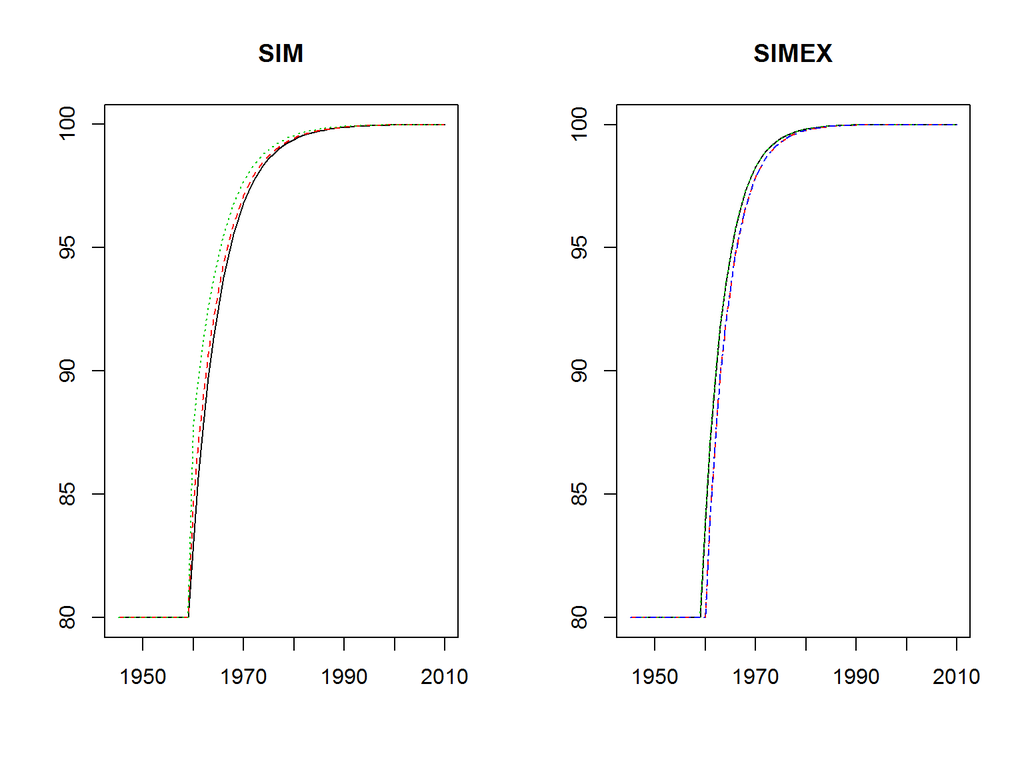

```r
#Doing the simulations
datasimex<-simulate(simex)
init = datasimex$baseline[66,]
simex<-sfc.addScenario(simex,"G",25,1960,2010,init)
datasimex<-simulate(simex)
datasim<-simulate(sim)
init = datasim$baseline[66,]
sim<-sfc.addScenario(sim,"G",25,1960,2010,init)
datasim<-simulate(sim)

#Plotting it all
layout(matrix(c(1,2),1,2))
matplot(sim$time,datasim$scenario_1[,c("H","C","Yd")],
    lty=1:3,type="l",xlab="",ylab="",main="SIM")
legend(x=1944,y=130,legend=c("Wealth","Consumption",
    "Disposable Income"), lty=1:3,bty="n")
matplot(simex$time,datasimex$scenario_1[,c("H","C","Yd",
    "Yd_e")],lty=1:4,type="l",xlab="",ylab="",main="SIMEX")
legend(x=1944,y=130,legend=c("Wealth","Consumption","Disposable Income",
   "Expecetd Disposable Income"),lty=1:4,bty="n")
```

## Computational implications

Let’s see how much time it takes to run sim:

```r
ptm <- proc.time()
data1<-simulate(sim)
print(paste("Elapsed time is ",proc.time()[3]-ptm[3],
                        "seconds"))
```

```
## [1] "Elapsed time is  4.88 seconds"
```

Now lets play with some of the parameters of the simulate function:

1. tolValue

```r
ptm <- proc.time()
data2<-simulate(sim,tolValue = 1e-3)
print(paste("Elapsed time is ",proc.time()[3]-ptm[3],"seconds"))
```

```
## [1] "Elapsed time is  0.25 seconds"
```

2. maxIter

```r
ptm <- proc.time()
data3<-simulate(sim, maxIter=10)
print(paste("Elapsed time is ",proc.time()[3]-ptm[3],"seconds"))
```

```
## [1] "Elapsed time is  0.270000000000003 seconds"
```

## Observing the results of the three simulations

```r
kable(round(t(cbind(data1$baseline[c(1,2,20,40,66),c("Y")],
        data2$baseline[c(1,2,20,40,66),c("Y")],
        data3$baseline[c(1,2,20,40,66),c("Y")])),digits=3))
```

| 1945 | 1946 | 1964 | 1984 | 2010 |
| --- | --- | --- | --- | --- |
| NA | 38.462 | 96.957 | 99.892 | 99.999 |
| NA | 38.464 | 96.874 | 99.577 | 99.911 |
| NA | 34.006 | 94.965 | 99.672 | 99.991 |

## Block Gauss-Seidel

The order of equations matters, if first compute variables that do not depend on current period, this speeds the process. Define blocks of equation independent from the others.

```r
print(simex$blocks)
```

```
## [[1]]
## [1] 7
##
## [[2]]
## [1] 3
##
## [[3]]
## [1] 6
##
## [[4]]
## [1] 8
##
## [[5]]
## [1] 2
##
## [[6]]
## [1] 1 4
##
## [[7]]
## [1] 5
```

## Simulation of SIMEX

```r
ptm <- proc.time()
dataex<-simulate(simex,tolValue = 1e-10)
print(paste("Elapsed time is ",proc.time()[3]-ptm[3]
                        ,"seconds"))
```

```
## [1] "Elapsed time is  0.200000000000003 seconds"
```

## Results for SIMEX

```r
kable(round(t(dataex$baseline[c(1,2,20,40,66),c("G","Y",
    "T","Yd","Yd_e","C","H","H_h")]),digits=3))
```

|  | 1945 | 1946 | 1964 | 1984 | 2010 |
| --- | --- | --- | --- | --- | --- |
| G | 20 | 20 | 20.000 | 20.000 | 20 |
| Y | NA | 20 | 98.559 | 99.983 | 100 |
| T | NA | 4 | 19.712 | 19.997 | 20 |
| Yd | 0 | 16 | 78.847 | 79.987 | 80 |
| Yd_e | NA | 0 | 78.559 | 79.983 | 80 |
| C | NA | 0 | 78.559 | 79.983 | 80 |
| H | 0 | 16 | 78.847 | 79.987 | 80 |
| H_h | 0 | 16 | 78.847 | 79.987 | 80 |

## Output data structure

- Output is a list of matrix where each element of the list are a scenario
- baseline
- scenario_i
- In the result matrix, there is a column indicating the number of iteration in the Gauss-Seidel algorithm per block of equations per period

```r
kable(dataex$baseline)
```

[output not shown]